# Interpreting Linear Regression Residual Plots

Ryan Yee

```r
library(tidyverse)
library(modelr)
```

# Introduction

We often refer to residual plots to check that our assumptions are reasonable when performing linear regression. We will demonstrate what residuals look like when these assumptions are not met.

## Define Plotting Functions

```r
plot_lm = function(data) {
  return(
    data %>%
      ggplot(aes(x, y)) +
      geom_point() +
      geom_smooth(method = "lm", se = FALSE, formula = "y ~ x")
  )
}

plot_resid = function(data) {
  return(
    data %>%
      ggplot(aes(x, resid)) +
      geom_point() +
      geom_hline(yintercept = 0, color = "red", linetype = "dashed")
  )
}
```

# Equal Variance

Let’s create some data where the equal variance assumption is violated.

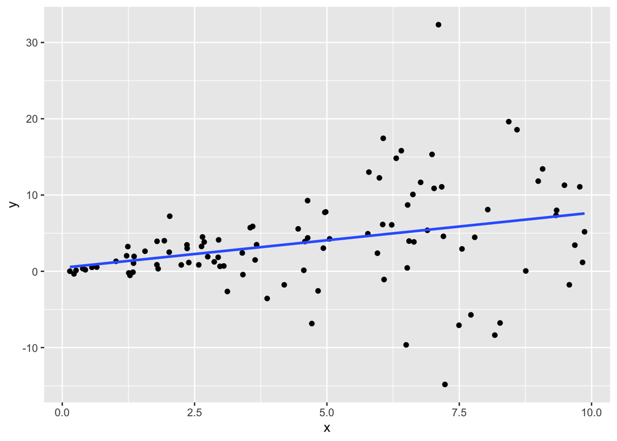

```r
# draw x's uniformally over interval [0, 10]
x = runif(100, min = 0, max = 10)

# assign y's as linear function of x's with some noise that depends on the value of x
y = x + x*rnorm(100)

uneq_var = tibble(x, y)
plot_lm(uneq_var)
```

Now, we fit a linear model with this data and look at the residuals.

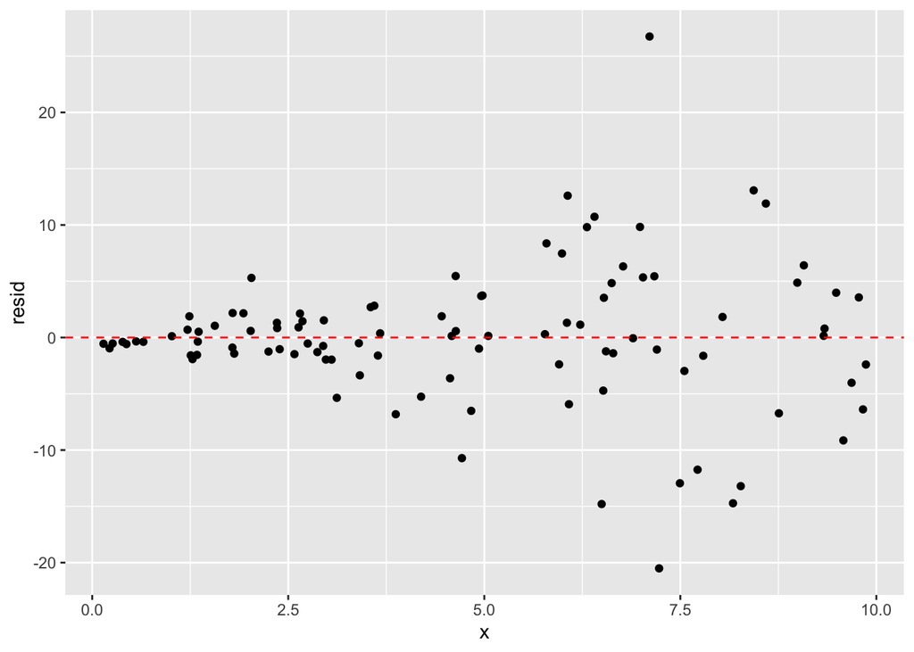

```r
uneq_var_lm = lm(y ~ x, data = uneq_var)

uneq_var %>%
  add_residuals(uneq_var_lm) %>%
  plot_resid()
```

We can clearly see that the residuals around $x=0$ are much less dispersed than the residuals around $x=10$. When the equal variance assumption is violated, we typically see a “funnel” shape to the residuals.

# Normal Error

Let’s create some data where the normal error assumption is violated.

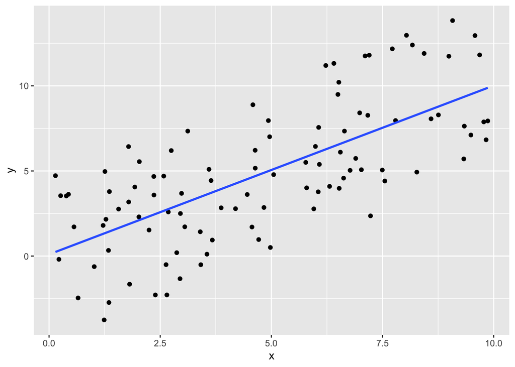

```r
# we will use the same x's as before

# assign y's as linear function of x's with uniform error
y = x + runif(100, min = -5, max = 5)

unif_err = tibble(x, y)
plot_lm(unif_err)
```

Now, we fit a linear model with this data and look at the residuals.

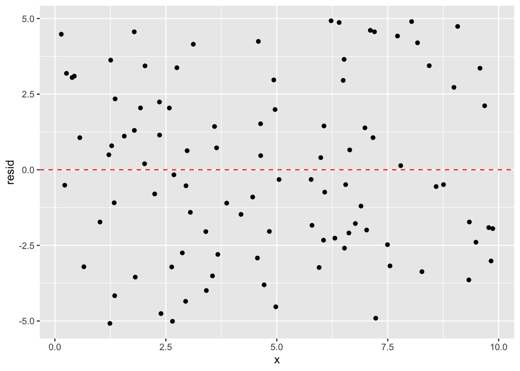

```r
unif_err_lm = lm(y ~ x, data = unif_err)

unif_err %>%
  add_residuals(unif_err_lm) %>%
  plot_resid()
```

This is what the error looks like with uniform error. Let’s also look at a more extreme example where we either have error 1 or -1.

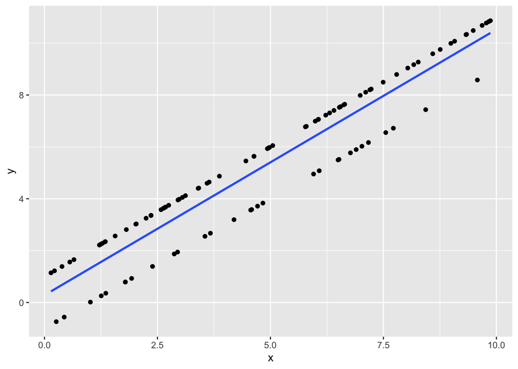

```r
# use the same x's as before

# assign y's as linear function of x's with error of -1 or 1
y = x + rbinom(10, 1, .5) * 2 -1

binom_err = tibble(x, y)
plot_lm(binom_err)
```

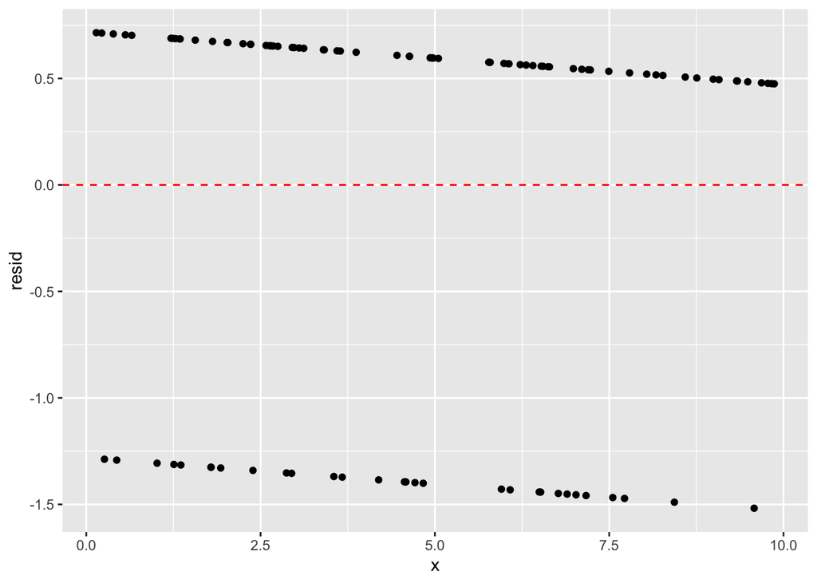

```r
binom_err_lm = lm(y ~ x, data = binom_err)

binom_err %>%
  add_residuals(binom_err_lm) %>%
  plot_resid()
```

Now we can see the error is definitely not normally distributed. If it were, there would be more observations close to 0.

# Independence

It is not always possible to determine if the independence assumption isn’t met by looking at residual plots. However, we will show one example where we can.

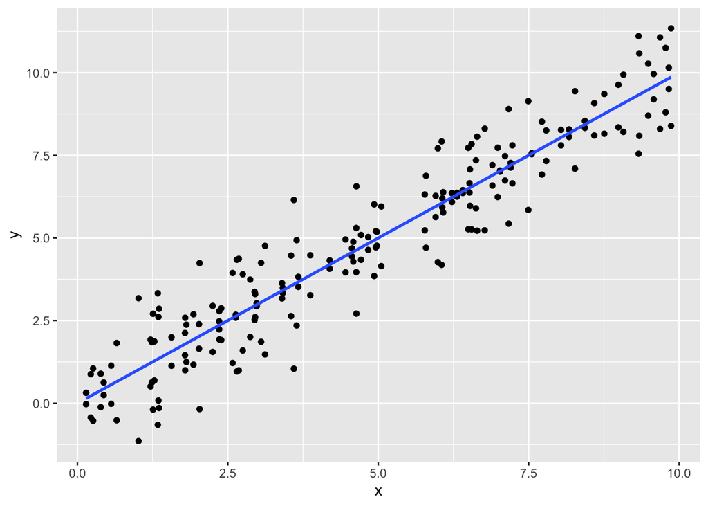

```r
# create some normal error
error = rnorm(100)

# create data frame where we add normal error to x's
add_error = tibble(x, y = x + error)

# create data frame where we subtract normal error to x's
subtract_error = tibble(x, y = x - error)

# combine these data frames. Note that we used each x twice so we do not have independent observations
dependent = bind_rows(add_error, subtract_error)
plot_lm(dependent)
```

Now let’s look at the residuals.

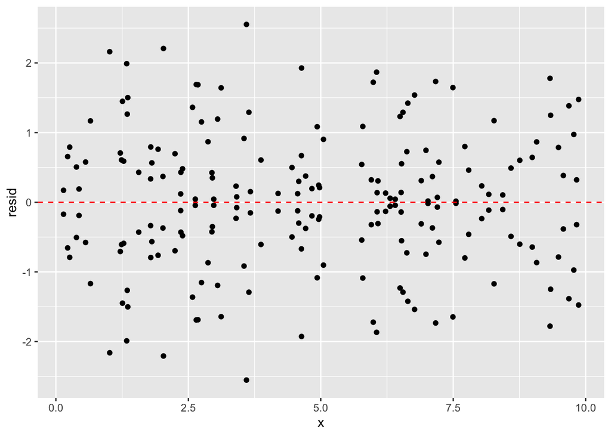

```r
dependent_lm = lm(y ~ x, data = dependent)

dependent %>%
  add_residuals(dependent_lm) %>%
  plot_resid()
```

Note that the error is symmetrical about zero.